# Downloading and preparing fishing for ISIMIP 3a Baltic mizer

Following the Hawaii model, I now sum *NomActive* to get two time series between 1961–2010. Then I calculate the average effort between 1992–2004, because the original model calibrated to average conditions between 1992–2002, but here we are asked to use up to year 2004 for calibrating. I divide the annual efforts by the average in the calibration time window and multiply by a factor. The Hawaii model uses 0.2 because that was used in the paper. The equivalent would be for me to use the average efforts in my calibration time window. Remember also fishing mortality is the product of selectivity ✕ catchability ✕ effort. For all species, selectivity and catchability were set to 1.

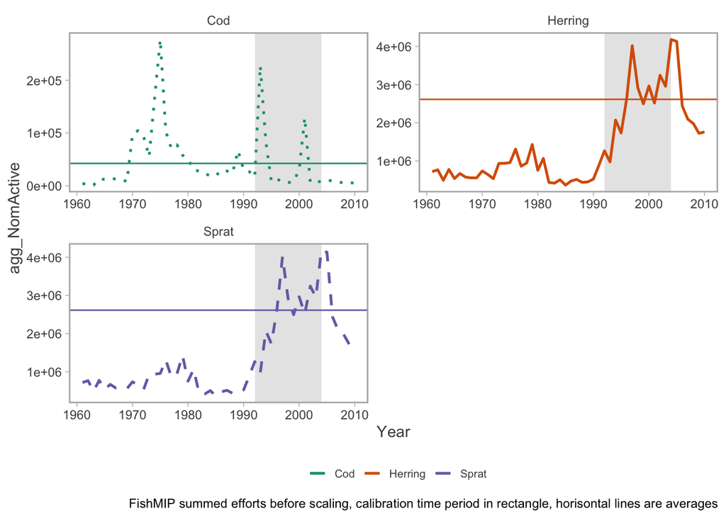

```r
all_effort_agg <- all_effort_sum %>%
  filter(Year >= 1961 & Year <= 2010) %>%
  group_by(sp, Year) %>%
  summarise(agg_NomActive = sum(sum_NomActive)) %>%
  ungroup()

# Now I need to split sprat and herring into two groups
all_effort_agg_cod <- all_effort_agg %>% filter(sp == "Cod")

all_effort_agg <- all_effort_agg_cod %>%
  bind_rows(all_effort_agg %>% filter(sp == "Sprat/Herring") %>% mutate(sp = "Sprat")) %>%
  bind_rows(all_effort_agg %>% filter(sp == "Sprat/Herring") %>% mutate(sp = "Herring"))

cal_tp_avg <- all_effort_agg %>%
  filter(Year >= 1992 & Year <= 2004) %>%
  group_by(sp) %>%
  summarise(avg_NomActive = mean(agg_NomActive),
            max_NomActive = max(agg_NomActive)) %>%
  ungroup()

# Plot time series of effort by species group
ggplot(all_effort_agg, aes(Year, agg_NomActive, color = sp, linetype = sp)) +
  geom_rect(xmin = 1992, xmax = 2004, ymin = -Inf, ymax = Inf, color = NA,
            fill = "grey90", alpha = 0.05,
            inherit.aes = FALSE) +
  geom_line(linewidth = 0.9) +
  facet_wrap(~sp, scales = "free", ncol = 2) +
  geom_hline(data = cal_tp_avg, aes(yintercept = avg_NomActive, color = sp)) +
  scale_linetype_manual(values = c(3, 1, 2)) +
  scale_color_brewer(palette = "Dark2", name = "") +
  guides(linetype = "none") +
  theme(legend.position = "bottom") +
  labs(caption = "FishMIP summed efforts before scaling, calibration time period in rectangle, horisontal lines are averages")
```

```r
all_effort_agg <- all_effort_agg %>%
  left_join(cal_tp_avg, by = "sp") %>%
  mutate(scaled_NomActive = agg_NomActive/avg_NomActive,
         scaled_NomActive_max = agg_NomActive/max_NomActive)

all_effort_agg %>% arrange(desc(scaled_NomActive_max))
```

```
# A tibble: 150 × 7
   sp       Year agg_NomActive avg_NomActive max_NomActive scaled_NomActive
   <chr>   <dbl>         <dbl>         <dbl>         <dbl>            <dbl>
 1 Cod      1975       277136.        42400.       227553.             6.54
 2 Cod      1993       227553.        42400.       227553.             5.37
 3 Sprat    2004      4180841.      2614071.      4180841.             1.60
 4 Herring  2004      4180841.      2614071.      4180841.             1.60
 5 Sprat    2005      4131236.      2614071.      4180841.             1.58
 6 Herring  2005      4131236.      2614071.      4180841.             1.58
 7 Sprat    1997      4019963.      2614071.      4180841.             1.54
 8 Herring  1997      4019963.      2614071.      4180841.             1.54
 9 Sprat    2002      3244814.      2614071.      4180841.             1.24
10 Herring  2002      3244814.      2614071.      4180841.             1.24
# ℹ 140 more rows
# ℹ 1 more variable: scaled_NomActive_max <dbl>
```

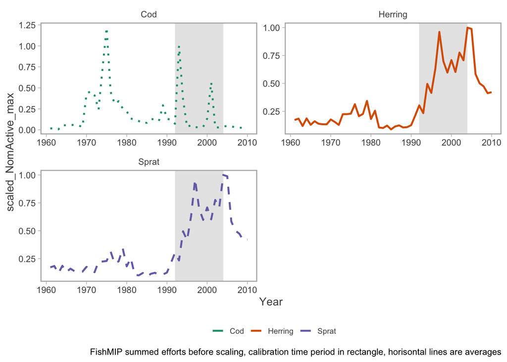

```r
# Plot the max-scales efforts
ggplot(all_effort_agg, aes(Year, scaled_NomActive_max, color = sp, linetype = sp)) +
  geom_rect(xmin = 1992, xmax = 2004, ymin = -Inf, ymax = Inf, color = NA,
            fill = "grey90", alpha = 0.05,
            inherit.aes = FALSE) +
  geom_line(linewidth = 0.9) +
  facet_wrap(~sp, scales = "free", ncol = 2) +
  scale_linetype_manual(values = c(3, 1, 2)) +
  scale_color_brewer(palette = "Dark2", name = "") +
  guides(linetype = "none") +
  theme(legend.position = "bottom") +
  labs(caption = "FishMIP summed efforts before scaling, calibration time period in rectangle, horisontal lines are averages")
```

Now we to multiply the relative FishMIP series by a factor. Here I use the average fishing mortality I had in the main model (Cod = 0.899, Herring = 0.306, Sprat = 0.340)

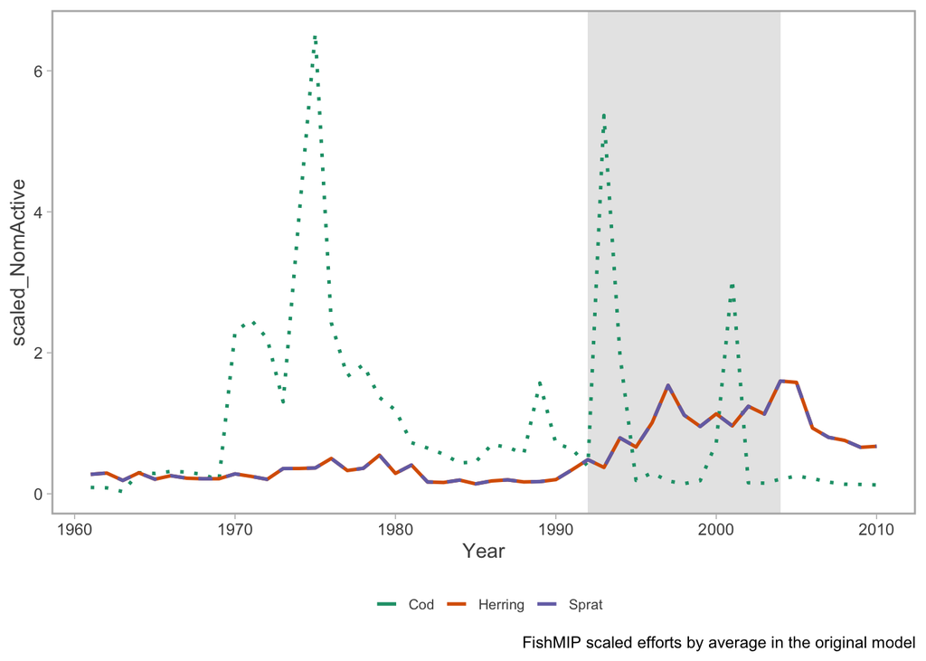

```r
avg_scalars <- data.frame(sp = c("Cod", "Herring", "Sprat"),
                          avg_scalars = c(0.899, 0.306, 0.340))

all_effort_agg <- all_effort_agg %>%
  left_join(avg_scalars, by = "sp") %>%
  mutate(scaled_NomActive_assess = scaled_NomActive*avg_scalars)

# Mean-scaled
all_effort_agg %>%
  ggplot(aes(Year, scaled_NomActive, color = sp, linetype = sp)) +
  geom_rect(xmin = 1992, xmax = 2004, ymin = -Inf, ymax = Inf, color = NA,
            fill = "grey90", alpha = 0.05,
            inherit.aes = FALSE) +
  geom_line(linewidth = 0.9) +
  scale_linetype_manual(values = c(3, 1, 2)) +
  scale_color_brewer(palette = "Dark2", name = "") +
  theme(legend.position = "bottom") +
  guides(linetype = "none") +
  labs(caption = "FishMIP scaled efforts by average in the original model")
```

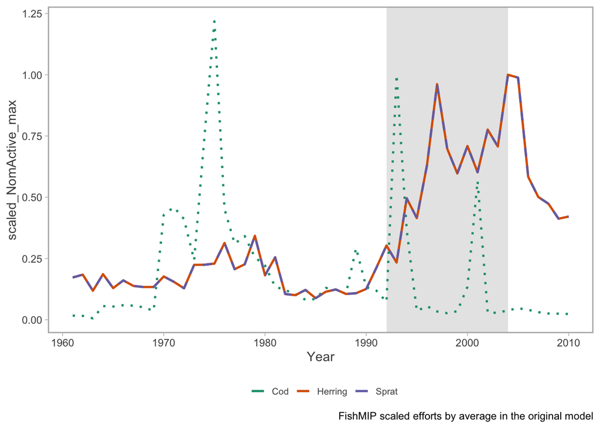

```r
# Max-scaled
all_effort_agg %>%
  ggplot(aes(Year, scaled_NomActive_max, color = sp, linetype = sp)) +
  geom_rect(xmin = 1992, xmax = 2004, ymin = -Inf, ymax = Inf, color = NA,
            fill = "grey90", alpha = 0.05,
            inherit.aes = FALSE) +
  geom_line(linewidth = 0.9) +
  scale_linetype_manual(values = c(3, 1, 2)) +
  scale_color_brewer(palette = "Dark2", name = "") +
  theme(legend.position = "bottom") +
  guides(linetype = "none") +
  labs(caption = "FishMIP scaled efforts by average in the original model")
```

Read in the fishing efforts I used in the calibration and compare with the FishMIP effort:

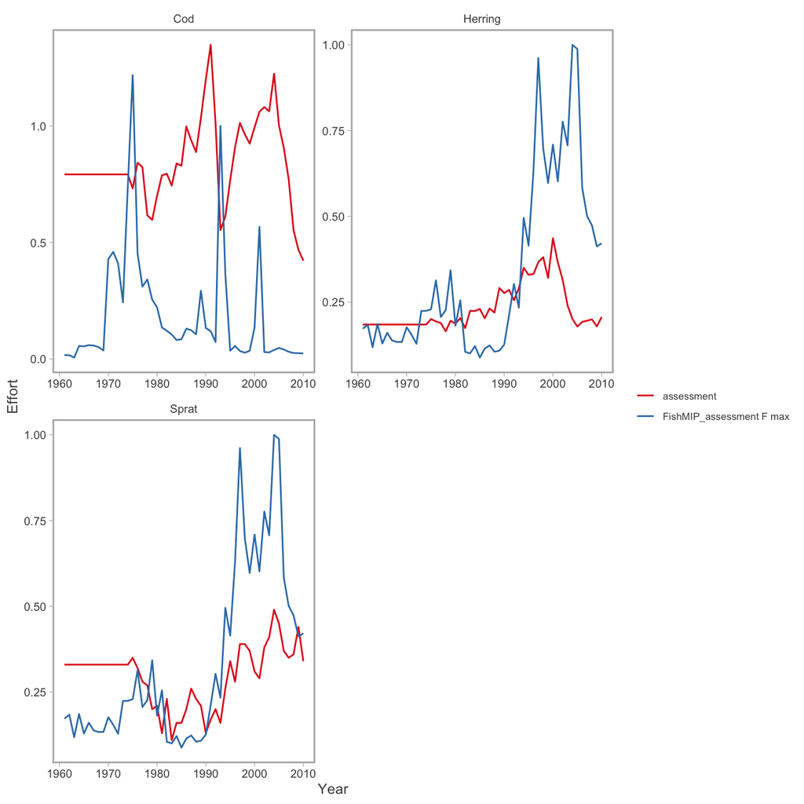

```r
# Load effort
projectEffort <- read_csv(paste0(home, "/baltic/params/projectEffort.csv"))[, 2:4] #%>%

# Add in Year
projectTemp_old <- read_csv(paste0(home, "/baltic/params/projectTemp.csv"))[, 2:3]

projectEffort <- projectEffort %>%
  mutate(year = projectTemp_old$Year) %>%
  filter(year >= 1961 & year <= 2010) %>%
  pivot_longer(cols = c("Cod", "Herring", "Sprat"), names_to = "sp", values_to = "effort") %>%
  mutate(source = "assessment")

# Add in FishMip effort
all_effort_agg_assess <- all_effort_agg %>%
  rename(effort = scaled_NomActive_assess,
         year = Year) %>%
  dplyr::select(sp, year, effort) %>%
  mutate(source = "FishMIP_assessment F")

all_effort_agg_assess_max <- all_effort_agg %>%
  rename(effort = scaled_NomActive_max,
         year = Year) %>%
  dplyr::select(sp, year, effort) %>%
  mutate(source = "FishMIP_assessment F max")

projectEffort <- bind_rows(projectEffort, all_effort_agg_assess, all_effort_agg_assess_max)

# Now scale the maximum to match the magnitude of the assessment F
projectEffort %>%
  filter(!source == "FishMIP_assessment F") %>%
  ggplot(aes(year, effort, color = source)) +
  geom_line() +
  facet_wrap(~sp, ncol = 2, scales = "free") +
  theme_sleek(base_size = 9) +
  scale_color_brewer(palette = "Set1", name = "") +
  labs(x = "Year", y = "Effort") +
  NULL
```

```r
# What's the best scaling factor? Fit a regression
d <- projectEffort %>%
  #filter(year >= 1992 & year <= 2004) %>%
  filter(!source == "FishMIP_assessment F") %>%
  dplyr::select(year, sp, effort, source) %>%
  pivot_wider(names_from = "source", values_from = "effort") %>%
  janitor::clean_names()

fit <- lm(assessment - fish_mip_assessment_f_max ~ 0 + sp, data = d) %>%
  broom::tidy()

sums <- d %>%
  summarise(mean = mean(assessment - fish_mip_assessment_f_max),
            median = median(assessment - fish_mip_assessment_f_max), .by = "sp")

# Re-scale
projectEffort %>%
  filter(source == "FishMIP_assessment F max") %>%
  arrange(effort)
```

```
# A tibble: 150 × 4
    year sp     effort source
   <dbl> <chr>   <dbl> <chr>
 1  1963 Cod   0.00571 FishMIP_assessment F max
 2  1962 Cod   0.0157  FishMIP_assessment F max
 3  1961 Cod   0.0168  FishMIP_assessment F max
 4  2010 Cod   0.0235  FishMIP_assessment F max
 5  2009 Cod   0.0248  FishMIP_assessment F max
 6  2008 Cod   0.0254  FishMIP_assessment F max
 7  1998 Cod   0.0269  FishMIP_assessment F max
 8  2003 Cod   0.0282  FishMIP_assessment F max
 9  2002 Cod   0.0292  FishMIP_assessment F max
10  2007 Cod   0.0309  FishMIP_assessment F max
# ℹ 140 more rows
```